# Fragmentation statistics

```r
library(Makurhini)
library(sf)
library(ggplot2)
```

## Overview

We explored the **MK_Fragmentation()** to estimate fragmentation statistics at the landscape and patch level.

## Example database

We loaded the “vegetation_patches” database with 142 patches of old-growth vegetation from the state of Chiapas, Mexico. The shapefile has 142 rows (patches), the first column corresponds to the id of the patch.

```r
data("vegetation_patches", package = "Makurhini")
nrow(vegetation_patches) # Number of patches
```

```
#> [1] 142
```

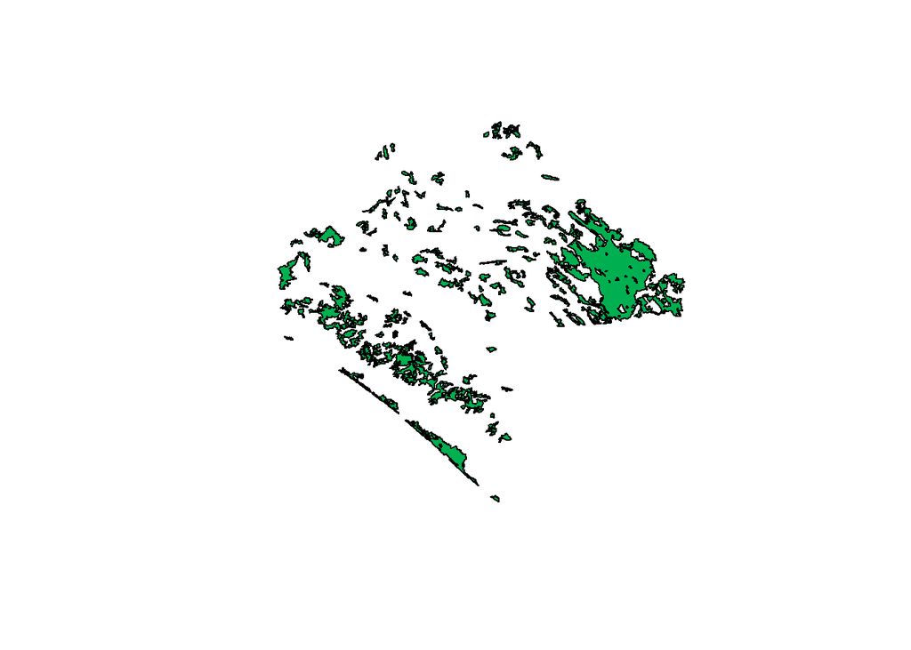

```r
plot(st_geometry(vegetation_patches), col = "#00B050")
```

## MK_Fragmentation()

To define the edge of the patches we will use a distance of 500 m from the limit of the patches (Haddad et al. 2015).

```r
Fragmentation_test <- MK_Fragmentation(patches = vegetation_patches, edge_distance = 500, plot = F, min_patch_area = 100, landscape_area = NULL, area_unit = "km2", perimeter_unit = "km")
```

### Exploring results

- The results are presented as a list, the first result is called *“Summary landscape metrics (Viewer Panel)”* and it has fragmentation statistics at landscape level.

```r
names(Fragmentation_test)
```

```
#> [1] "Summary landscape metrics (Viewer Panel)"
#> [2] "Patch statistics shapefile"
```

```r
Fragmentation_test$`Summary landscape metrics (Viewer Panel)`
```

| Metric | Value |
| --- | --- |
| Patch area (km2) | 12792.201 |
| Number of patches | 142.000 |
| Size (mean) | 90.086 |
| Patches < minimum patch area | 126.000 |
| Patches < minimum patch area (%) | 30.802 |
| Total edge | 12297.533 |
| Edge density | 0.961 |
| Total Core Area (km2) | 7622.384 |
| Cority | 1.000 |
| Shape Index (mean) | 2.792 |
| FRAC (mean) | 1.468 |
| MESH (km2) | 1543.147 |

- The second output *“Patch statistics shapefile”* is a shapefile with patch level fragmentation statistics that can be saved using write_sf() from *‘sf’* package (https://cran.r-project.org/web/packages/sf/index.html).

```r
head(Fragmentation_test[[2]])
```

```
#> Simple feature collection with 6 features and 9 fields
#> geometry type:  POLYGON
#> dimension:      XY
#> bbox:           xmin: 3542152 ymin: 498183.1 xmax: 3711426 ymax: 696540.5
#> CRS:            +proj=lcc +lat_1=17.5 +lat_2=29.5 +lat_0=12 +lon_0=-102 +x_0=2500000 +y_0=0 +datum=WGS84 +units=m +no_defs
#>   id     Area       CA CAPercent Perimeter EdgePercent  PARA ShapeIndex  FRAC
#> 1  1 4195.569 3541.381    84.408  1412.046      15.592 2.971      6.150 1.407
#> 2  2   60.223   11.941    19.828   167.982      80.172 0.359      6.106 1.824
#> 3  3   48.866    6.210    12.708   127.049      87.292 0.385      5.127 1.778
#> 4  4   15.188    7.421    48.861    18.536      51.139 0.819      1.342 1.127
#> 5  5   33.272   13.088    39.336    55.038      60.664 0.605      2.692 1.496
#> 6  6   53.134   11.356    21.372   111.123      78.628 0.478      4.300 1.674
#>                         geometry
#> 1 POLYGON ((3676911 589967.3,...
#> 2 POLYGON ((3558044 696202.5,...
#> 3 POLYGON ((3569169 687776.4,...
#> 4 POLYGON ((3547317 685713.2,...
#> 5 POLYGON ((3567471 684357.4,...
#> 6 POLYGON ((3590569 672451.7,...
```

- To save the shapefile you can use the ‘write_sf()’ function from ‘sf’ package: write_sf(Fragmentacion_test[[2]], “…/folder/fragmentacion.shp”)

### Viewing the results

We can visualize the static at the patch level using the default *plot()* function or other spatial information display packages like the *‘tmap’* package, for example:

- Core area (%):

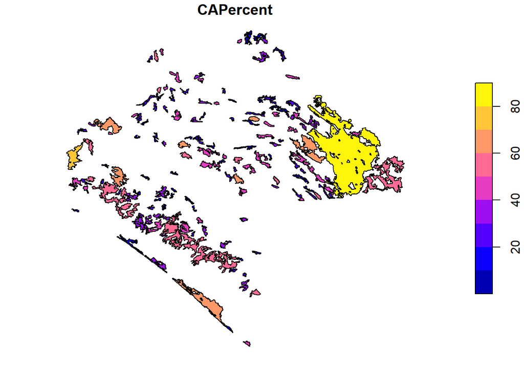

- Edge (%)

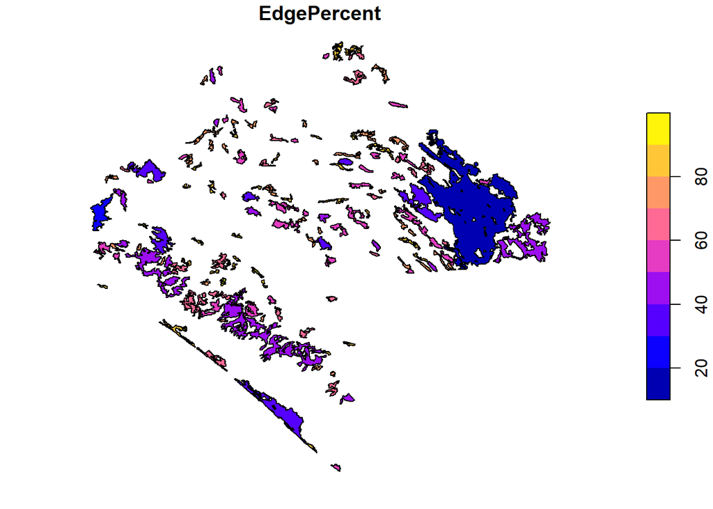

- Perimeter-area ratio (PARA)

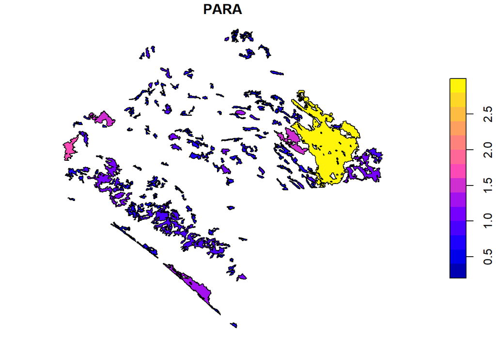

- Shape Index

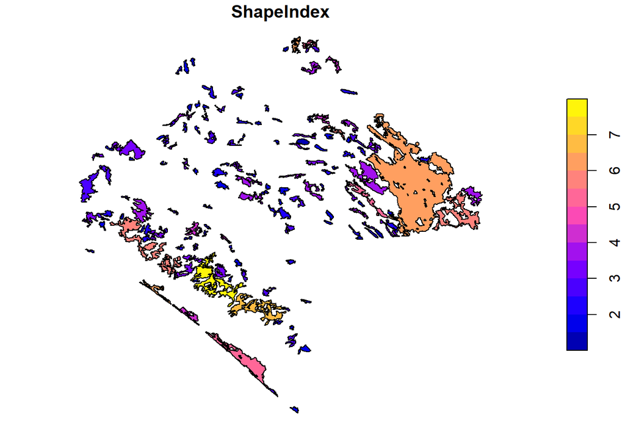

- Fractal Dimension Index

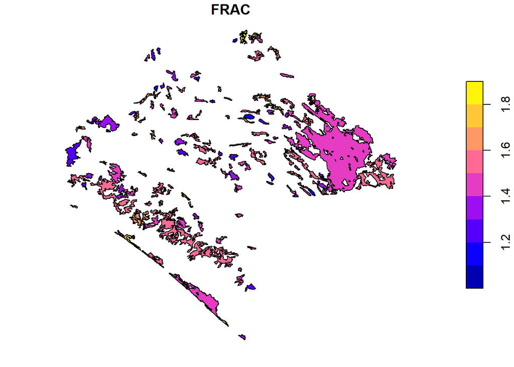

### Exploring other edge depths

We can make a loop where we explore different edge depths. In the following example, We will explore 10 edge depths (*edge_distance argument*): 100, 200, 300, 400, 500, 600, 700, 800, 900 and 1000 meters. We will apply the *‘MK_Fragmentation’* function using the previous distances and then, we will extract the core area percentage and edge percentage statistics. Finally, we will plot the average of the patch core area percentage and edge percentage (% core area + % edge = 100%).

```
#>   Edge.distance      Type Percentage
#> 1           100 Core Area   83.50517
#> 2           100      Edge   16.49483
#> 3           200 Core Area   68.18519
#> 4           200      Edge   31.81481
#> 5           300 Core Area   54.77213
#> 6           300      Edge   45.22787
```

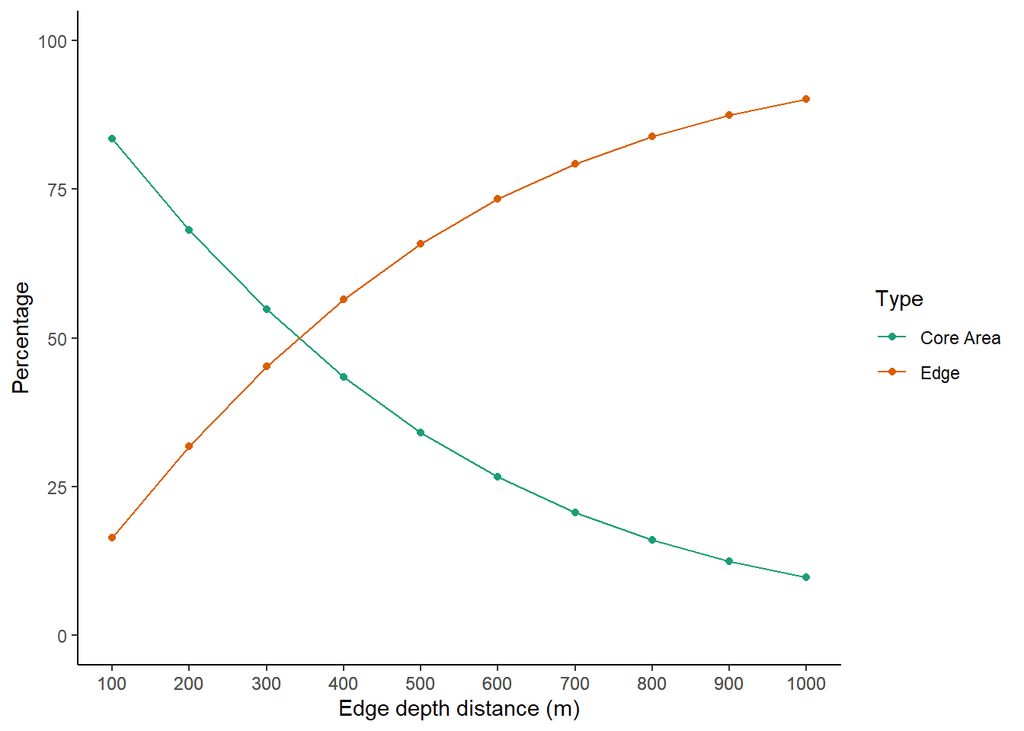

The average core area percentage (average patch area that has the least possible edge effect) for all patches decreases by more than 70% when considering an edge effect with an edge depth distance of 1 km.

| Edge depth distance (m) | CoreArea (%) |
| --- | --- |
| 100 | 83.5% |
| 500 | 34.14% |
| 1000 | 9.78% |

**Reference**:

- INEGI. (2013). Conjunto de datos vectoriales de uso del suelo y vegetación, serie V (capa unión), escala 1:250,000. Instituto Nacional de Estadística y Geografía, Aguascalientes.
- McGarigal, K., S. A. Cushman, M. C. Neel, and E. Ene. 2002. FRAGSTATS: Spatial Pattern Analysis Program for Categorical Maps. Computer software program produced by the authors at the University of Massachusetts, Amherst. Available at the following web site: www.umass.edu/landeco/research/fragstats/fragstats.html.
- Haddad et al. (2015). Science Advances 1(2):e1500052. DOI: 10.1126/sciadv.1500052.